# CUDA LAB - Transfer Learning

# Comparison between Finetune Resnet and Resnet feature extractor

### 2) Feature extractor resnet trains faster as it took 41.223 seconds and finetune resnet took 46.904 seconds.

### 3) As seen in the plots below, validation loss of finetune resnet is relatively smoother while train loss is quite similar of both.

```python
df4 = pd.read_csv('feature_fixed_resnet.csv')
df=pd.DataFrame()
print("Accuracy Comparison of the Finetune Resnet and Resnet feature extractor models")
df['Epochs'] = df1['Epochs']
df['finetune train loss'] = df1['Train Loss']
df['feature train loss'] = df4['Train Loss']
df['finetune val loss'] = df1['Validation Loss']
df['feature val loss'] = df4['Validation Loss']
df['finetune acc'] = df1['Validation Acc']
df['feature acc'] = df4['Validation Acc']

df.head(10)
```

```
Accuracy Comparison of the Finetune Resnet and Resnet feature extractor models
```

|  | Epochs | finetune train loss | feature train loss | finetune val loss | feature val loss | finetune acc | feature acc |
| --- | --- | --- | --- | --- | --- | --- | --- |
| 0 | 0 | 0.041905 | 0.099893 | 0.849376 | 1.073052 | 40.000000 | 33.333333 |
| 1 | 1 | 0.104246 | 0.026557 | 0.000652 | 0.339643 | 100.000000 | 85.000000 |
| 2 | 2 | 0.070442 | 0.115145 | 0.025318 | 0.124691 | 98.333333 | 96.666667 |
| 3 | 3 | 0.020407 | 0.050999 | 0.011660 | 0.039936 | 100.000000 | 98.333333 |
| 4 | 4 | 0.006721 | 0.021343 | 0.080117 | 0.049368 | 95.000000 | 96.666667 |
| 5 | 5 | 0.012821 | 0.024935 | 0.024871 | 0.004478 | 98.333333 | 100.000000 |
| 6 | 6 | 0.004384 | 0.015894 | 0.098044 | 0.186262 | 95.000000 | 91.666667 |
| 7 | 7 | 0.001432 | 0.007365 | 0.026269 | 0.012963 | 98.333333 | 100.000000 |
| 8 | 8 | 0.000580 | 0.007446 | 0.038011 | 0.011580 | 98.333333 | 100.000000 |
| 9 | 9 | 0.000640 | 0.001262 | 0.028122 | 0.007279 | 98.333333 | 100.000000 |

```
[Text(0.5, 0, 'Epochs'), Text(0, 0.5, 'Train Loss')]
```

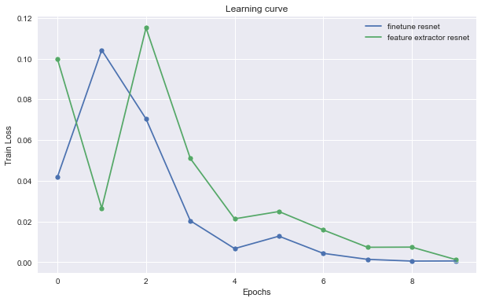

```python
fig = plt.figure()
fig = plt.figure(figsize=(10,6))
p = sns.lineplot(data=df1, x="Epochs", y="Train Loss",label = 'finetune resnet')
p = sns.scatterplot(data=df1, x="Epochs", y="Train Loss")
p = sns.lineplot(data=df4, x="Epochs", y="Train Loss", label='feature extractor resnet')
p = sns.scatterplot(data=df4, x="Epochs", y="Train Loss")
plt.legend()
p.set_title("Learning curve")   # change here
p.set(xlabel='Epochs', ylabel='Train Loss')
```

```
[Text(0.5, 0, 'Epochs'), Text(0, 0.5, 'Validation Loss')]
```

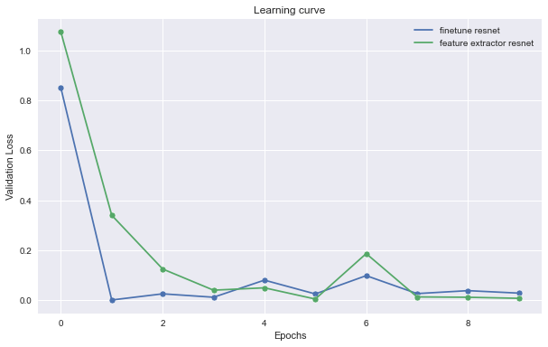

```python
fig = plt.figure()
fig = plt.figure(figsize=(10,6))
p = sns.lineplot(data=df1, x="Epochs", y="Validation Loss",label = 'finetune resnet')
p = sns.scatterplot(data=df1, x="Epochs", y="Validation Loss")
p = sns.lineplot(data=df4, x="Epochs", y="Validation Loss", label='feature extractor resnet')
p = sns.scatterplot(data=df4, x="Epochs", y="Validation Loss")
plt.legend()
p.set_title("Learning curve")   # change here
p.set(xlabel='Epochs', ylabel='Validation Loss')
```

```
[Text(0.5, 0, 'Epochs'), Text(0, 0.5, 'Validation Acc')]
```

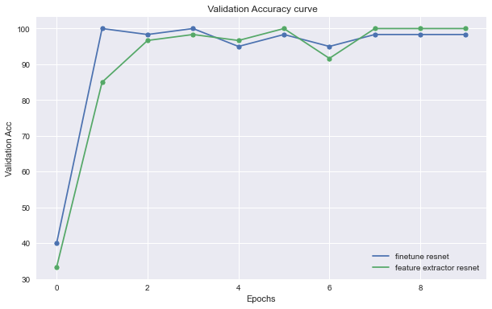

```python
fig = plt.figure()
fig = plt.figure(figsize=(10,6))
p = sns.lineplot(data=df1, x="Epochs", y="Validation Acc",label = 'finetune resnet')
p = sns.scatterplot(data=df1, x="Epochs", y="Validation Acc")
p = sns.lineplot(data=df4, x="Epochs", y="Validation Acc", label='feature extractor resnet')
p = sns.scatterplot(data=df4, x="Epochs", y="Validation Acc")
plt.legend()
p.set_title(" Validation Accuracy curve")   # change here
p.set(xlabel='Epochs', ylabel='Validation Acc')
```

# Train a ResNet feature extractor with an SVM classifier

### Approach: Here the last layer i.e. "fc" layer is removed and we get output of the "avgpool" of resnet18. This output from each image is stored and this new output becomes input to an SVM

```python
model = models.resnet18(pretrained=True)  # https://github.com/pytorch/vision/blob/master/torchvision/models/resnet.py
newmodel = torch.nn.Sequential(*(list(model.children())[:-1]))

newmodel.to(device)
print(newmodel)
```

```
Sequential(
  (0): Conv2d(3, 64, kernel_size=(7, 7), stride=(2, 2), padding=(3, 3), bias=False)
  (1): BatchNorm2d(64, eps=1e-05, momentum=0.1, affine=True, track_running_stats=True)
  (2): ReLU(inplace=True)
  (3): MaxPool2d(kernel_size=3, stride=2, padding=1, dilation=1, ceil_mode=False)
  (4): Sequential(
    (0): BasicBlock(
      (conv1): Conv2d(64, 64, kernel_size=(3, 3), stride=(1, 1), padding=(1, 1), bias=False)
      (bn1): BatchNorm2d(64, eps=1e-05, momentum=0.1, affine=True, track_running_stats=True)
      (relu): ReLU(inplace=True)
      (conv2): Conv2d(64, 64, kernel_size=(3, 3), stride=(1, 1), padding=(1, 1), bias=False)
      (bn2): BatchNorm2d(64, eps=1e-05, momentum=0.1, affine=True, track_running_stats=True)
    )
    (1): BasicBlock(
      (conv1): Conv2d(64, 64, kernel_size=(3, 3), stride=(1, 1), padding=(1, 1), bias=False)
      (bn1): BatchNorm2d(64, eps=1e-05, momentum=0.1, affine=True, track_running_stats=True)
      (relu): ReLU(inplace=True)
      (conv2): Conv2d(64, 64, kernel_size=(3, 3), stride=(1, 1), padding=(1, 1), bias=False)
      (bn2): BatchNorm2d(64, eps=1e-05, momentum=0.1, affine=True, track_running_stats=True)
    )
  )
  (5): Sequential(
    (0): BasicBlock(
      (conv1): Conv2d(64, 128, kernel_size=(3, 3), stride=(2, 2), padding=(1, 1), bias=False)
      (bn1): BatchNorm2d(128, eps=1e-05, momentum=0.1, affine=True, track_running_stats=True)
      (relu): ReLU(inplace=True)
      (conv2): Conv2d(128, 128, kernel_size=(3, 3), stride=(1, 1), padding=(1, 1), bias=False)
      (bn2): BatchNorm2d(128, eps=1e-05, momentum=0.1, affine=True, track_running_stats=True)
      (downsample): Sequential(
        (0): Conv2d(64, 128, kernel_size=(1, 1), stride=(2, 2), bias=False)
        (1): BatchNorm2d(128, eps=1e-05, momentum=0.1, affine=True, track_running_stats=True)
      )
    )
    (1): BasicBlock(
      (conv1): Conv2d(128, 128, kernel_size=(3, 3), stride=(1, 1), padding=(1, 1), bias=False)
      (bn1): BatchNorm2d(128, eps=1e-05, momentum=0.1, affine=True, track_running_stats=True)
      (relu): ReLU(inplace=True)
      (conv2): Conv2d(128, 128, kernel_size=(3, 3), stride=(1, 1), padding=(1, 1), bias=False)
      (bn2): BatchNorm2d(128, eps=1e-05, momentum=0.1, affine=True, track_running_stats=True)
    )
```

[output cut: 28 more lines]

```
      (downsample): Sequential(
        (0): Conv2d(256, 512, kernel_size=(1, 1), stride=(2, 2), bias=False)
        (1): BatchNorm2d(512, eps=1e-05, momentum=0.1, affine=True, track_running_stats=True)
      )
    )
    (1): BasicBlock(
      (conv1): Conv2d(512, 512, kernel_size=(3, 3), stride=(1, 1), padding=(1, 1), bias=False)
      (bn1): BatchNorm2d(512, eps=1e-05, momentum=0.1, affine=True, track_running_stats=True)
      (relu): ReLU(inplace=True)
      (conv2): Conv2d(512, 512, kernel_size=(3, 3), stride=(1, 1), padding=(1, 1), bias=False)
      (bn2): BatchNorm2d(512, eps=1e-05, momentum=0.1, affine=True, track_running_stats=True)
    )
  )
  (8): AdaptiveAvgPool2d(output_size=(1, 1))
)
```

```python
# Data augmentation and normalization for training
# Just normalization for validation
data_transforms = {
    'train': transforms.Compose([
        transforms.RandomResizedCrop(256,scale=(0.95, 1.0), ratio=(1.0, 1.1)),
        #transforms.ColorJitter(brightness=2, contrast=2, saturation=3, hue=0.3),
        #transforms.RandomHorizontalFlip(),
        transforms.ToTensor(),
        transforms.Normalize([0.485, 0.456, 0.406], [0.229, 0.224, 0.225])
    ]),
    'val': transforms.Compose([
        transforms.Resize(256),
        transforms.CenterCrop(256),
        transforms.ToTensor(),
        transforms.Normalize([0.485, 0.456, 0.406], [0.229, 0.224, 0.225])
    ]),
}
#data_dir = 'data/hymenoptera_data'
data_dir = 'data/robot_and_people'

train_dataset = datasets.ImageFolder(os.path.join(data_dir, "train"), data_transforms["train"])
#valid_dataset = datasets.ImageFolder(os.path.join(data_dir, "val"), data_transforms["val"])

N_train = len(train_dataset)
#N_valid = len(valid_dataset)
print(f"Training set size: {N_train} images")
#print(f"Valdiation set size: {N_valid} images")

train_loader = torch.utils.data.DataLoader(train_dataset, batch_size=1, shuffle=True, num_workers=4)
#valid_loader = torch.utils.data.DataLoader(valid_dataset, batch_size=32, shuffle=True, num_workers=4)
```

```
Training set size: 420 images
```

```python
# https://www.kaggle.com/winnie19900705/feature-extraction-resnet50-svm
features_array = np.zeros((420,512))
label_array = np.zeros((420))
i=0
with torch.no_grad():
    for images, labels in train_loader:
        images = images.to(device)
        labels = labels.to("cpu")

        # Forward pass only to get logits/output
        outputs = newmodel(images)
        features = outputs.reshape(512,)
        #print(features)
        features = features.to("cpu")
        features_array[i,:] = features.numpy()
        label_array[i] = labels.numpy()
        features = features.to(device)
        i=i+1
```

```python
df = pd.DataFrame(features_array)
df1 = pd.DataFrame(label_array)
```

```python
Xtrain, Xtest, ytrain, ytest = train_test_split(df, df1, test_size=0.2)
```

```python
from sklearn.svm import SVC
clf = SVC()
start = time.time()
clf.fit(Xtrain, ytrain)
preds = clf.predict(Xtest)
end = time.time()
```

```python
print("Time elapsed = ",end-start," seconds")
```

```
Time elapsed =  0.025962114334106445  seconds
```

```python
from sklearn.metrics import accuracy_score, confusion_matrix, classification_report
print(accuracy_score(ytest, preds))
```

```
0.9523809523809523
```

# Comparison among ResNet feature extractor with an SVM classifier, Fine-Tuned Resnet and the Fixed-ResNet + MLP classifier